# try_analysis_two

```r
m1 <- lm(degree_of_coh ~ ave_log_error + event_topic + ave_log_error:event_topic, dt2_full)
summary(m1) ### the coefficient of ave_log_error is significant
```

```
##
## Call:
## lm(formula = degree_of_coh ~ ave_log_error + event_topic + ave_log_error:event_topic,
##     data = dt2_full)
##
## Residuals:
##      Min       1Q   Median       3Q      Max
## -0.56274 -0.26021 -0.08203  0.27353  0.73979
##
## Coefficients:
##                                  Estimate Std. Error t value Pr(>|t|)
## (Intercept)                       0.71012    0.07537   9.422  < 2e-16 ***
## ave_log_error                    -0.58952    0.15560  -3.789 0.000211 ***
## event_topicweather               -0.17316    0.09972  -1.737 0.084302 .
## ave_log_error:event_topicweather  0.03602    0.20689   0.174 0.861981
## ---
## Signif. codes:  0 '***' 0.001 '**' 0.01 '*' 0.05 '.' 0.1 ' ' 1
##
## Residual standard error: 0.3454 on 168 degrees of freedom
## Multiple R-squared:  0.1899, Adjusted R-squared:  0.1754
## F-statistic: 13.13 on 3 and 168 DF,  p-value: 9.618e-08
```

Does the the combination of event types matter (For example, are people more likely to make errors (aka. behave against the probability theory) when they are judging “or” events and “and” events. In other words, will the “1” responses for conjunction and disjunction events be less than the “1” responses for marginal and conjunction/disjunction events? )

```r
dt2_two <- dt2 %>%
  pivot_longer(starts_with("coh_"), names_to = "combination_of_two", values_to = "coherence_two")

a1_coh_two <- aov_ez("pid", "coherence_two",dt2_two, between = "condition", within = c("combination_of_two", "event_topic"))
```

```
## Converting to factor: condition
```

```
## Contrasts set to contr.sum for the following variables: condition
```

```r
a1_coh_two
```

```
## Anova Table (Type 3 tests)
##
## Response: coherence_two
##                                     Effect           df  MSE       F   ges p.value
## 1                                condition        1, 98 0.34    0.01 <.001    .932
## 2                       combination_of_two 1.92, 188.45 0.09  4.39 *  .009    .015
## 3             condition:combination_of_two 1.92, 188.45 0.09    1.75  .004    .179
## 4                              event_topic        1, 98 0.21 7.91 **  .019    .006
## 5                    condition:event_topic        1, 98 0.21  2.79 +  .007    .098
## 6           combination_of_two:event_topic 1.94, 190.23 0.07    1.61  .003    .202
## 7 condition:combination_of_two:event_topic 1.94, 190.23 0.07 5.96 **  .010    .003
## ---
## Signif. codes:  0 '***' 0.001 '**' 0.01 '*' 0.05 '+' 0.1 ' ' 1
##
## Sphericity correction method: GG
```

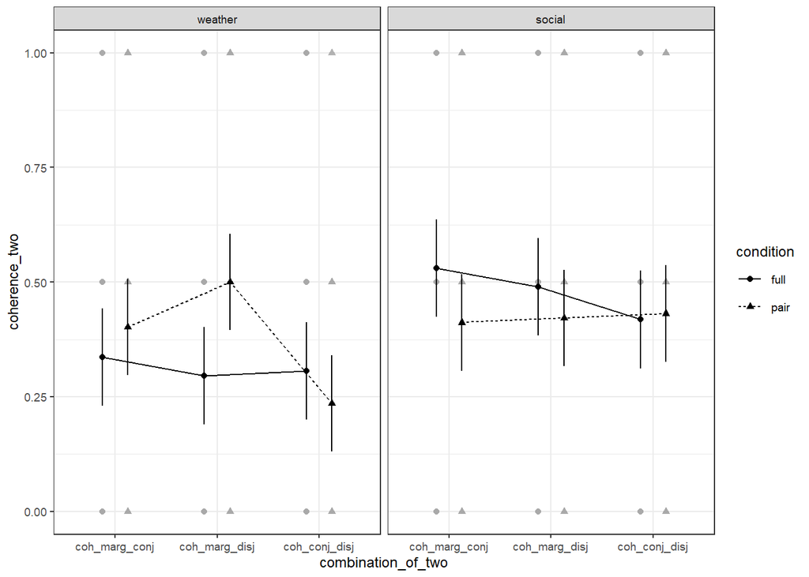

```r
afex_plot(a1_coh_two, "combination_of_two", "condition", "event_topic") ###  the interaction condition:combination_of_two:event_topic is significant
```

```r
dt2_exclu_two <- dt2_exclude %>%
   pivot_longer(starts_with("coh_"), names_to = "combination_of_two", values_to = "coherence_two")

a2_coh_two <- aov_ez("pid", "coherence_two",dt2_exclu_two, between = "condition", within = c("combination_of_two", "event_topic"))
```

```
## Converting to factor: condition
```

```
## Contrasts set to contr.sum for the following variables: condition
```

```r
a2_coh_two
```

```
## Anova Table (Type 3 tests)
##
## Response: coherence_two
##                                     Effect           df  MSE         F  ges p.value
## 1                                condition        1, 78 0.26 27.78 *** .094   <.001
## 2                       combination_of_two 1.94, 151.14 0.11 21.36 *** .061   <.001
## 3             condition:combination_of_two 1.94, 151.14 0.11  7.82 *** .023   <.001
## 4                              event_topic        1, 78 0.22    3.08 + .010    .083
## 5                    condition:event_topic        1, 78 0.22      0.65 .002    .422
## 6           combination_of_two:event_topic 1.99, 154.98 0.10    3.85 * .011    .024
## 7 condition:combination_of_two:event_topic 1.99, 154.98 0.10      0.71 .002    .492
## ---
## Signif. codes:  0 '***' 0.001 '**' 0.01 '*' 0.05 '+' 0.1 ' ' 1
##
## Sphericity correction method: GG
```

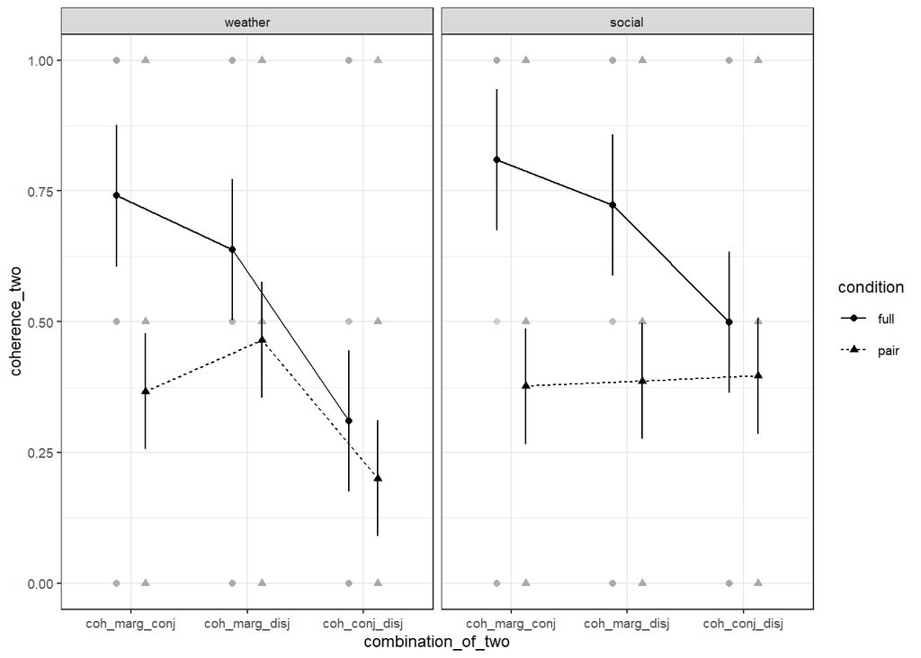

```r
afex_plot(a2_coh_two, "combination_of_two", "condition", "event_topic") ###  the interaction condition:combination_of_two:event_topic is not significant
```

Considering the order of the events

```r
dt2$marginal_order <- ifelse (dt2$order == "marginal_disjunction_conjunction" | dt2$order ==  "marginal_conjunction_disjunction" , "first",
                          ifelse(dt2$order == "disjunction_marginal_conjunction" | dt2$order ==  "conjunction_marginal_disjunction" | dt2$order == "disjunction_conjunction_marginal" | dt2$order ==  "conjunction_disjunction_marginal", "latter",
                                        "NA"))

dt2 %>% group_by(pid, marginal_order) %>% count()
```

```
## # A tibble: 180 x 3
## # Groups:   pid, marginal_order [180]
##    pid                      marginal_order     n
##    <chr>                    <chr>          <int>
##  1 55ad6781fdf99b649ca5a53f first              1
##  2 55ad6781fdf99b649ca5a53f latter             3
##  3 57e928630cb6700001dd8f8a first              1
##  4 57e928630cb6700001dd8f8a latter             2
##  5 5ae194995f327e0001fbb23e first              1
##  6 5ae194995f327e0001fbb23e latter             3
##  7 5b38a184dd6af000014ced7f first              1
##  8 5b38a184dd6af000014ced7f latter             2
##  9 5b9a16df2b00aa0001b2be06 latter             4
## 10 5ba4e5c0236c690001d2b3ca first              1
## # ... with 170 more rows
```

```r
dt2_exclude$marginal_order <- ifelse (dt2_exclude$order == "marginal_disjunction_conjunction" | dt2_exclude$order ==  "marginal_conjunction_disjunction" , "first",
                          ifelse(dt2_exclude$order == "disjunction_marginal_conjunction" | dt2_exclude$order ==  "conjunction_marginal_disjunction" | dt2_exclude$order == "disjunction_conjunction_marginal" | dt2_exclude$order ==  "conjunction_disjunction_marginal", "latter",
                                        "NA"))

dt2_exclude %>% group_by(pid, marginal_order) %>% count()
```

```
## # A tibble: 162 x 3
## # Groups:   pid, marginal_order [162]
##    pid                      marginal_order     n
##    <chr>                    <chr>          <int>
##  1 55ad6781fdf99b649ca5a53f latter             3
##  2 57e928630cb6700001dd8f8a first              1
##  3 57e928630cb6700001dd8f8a latter             1
##  4 5ae194995f327e0001fbb23e first              1
##  5 5ae194995f327e0001fbb23e latter             3
##  6 5b38a184dd6af000014ced7f first              1
##  7 5b38a184dd6af000014ced7f latter             1
##  8 5b9a16df2b00aa0001b2be06 latter             4
##  9 5ba4e5c0236c690001d2b3ca first              1
## 10 5ba4e5c0236c690001d2b3ca latter             2
## # ... with 152 more rows
```

```r
dt3 <- dt2 %>% filter()
```

Question 3: who is more rational?

```r
## including logical errors


r1 <- lm(degree_of_coh ~ numeracy_score*event_topic*numeracy_score:event_topic*response_time, dt2)
summary(r1)
```

```
##
## Call:
## lm(formula = degree_of_coh ~ numeracy_score * event_topic * numeracy_score:event_topic *
##     response_time, data = dt2)
##
## Residuals:
##      Min       1Q   Median       3Q      Max
## -0.65220 -0.30106 -0.05712  0.25566  0.76044
##
## Coefficients:
##                                                   Estimate Std. Error t value Pr(>|t|)
## (Intercept)                                      3.371e-01  1.696e-01   1.988   0.0476 *
## numeracy_score                                  -9.292e-03  3.745e-02  -0.248   0.8042
## event_topicweather                              -1.222e-01  2.287e-01  -0.534   0.5935
## response_time                                    6.063e-05  1.237e-04   0.490   0.6243
## numeracy_score:event_topicweather                3.550e-02  5.081e-02   0.699   0.4851
## numeracy_score:response_time                     1.190e-05  2.677e-05   0.444   0.6570
## event_topicweather:response_time                -6.916e-05  1.651e-04  -0.419   0.6755
## numeracy_score:event_topicweather:response_time -5.821e-06  3.601e-05  -0.162   0.8717
## ---
## Signif. codes:  0 '***' 0.001 '**' 0.01 '*' 0.05 '.' 0.1 ' ' 1
##
## Residual standard error: 0.3534 on 368 degrees of freedom
## Multiple R-squared:  0.05503,    Adjusted R-squared:  0.03706
## F-statistic: 3.062 on 7 and 368 DF,  p-value: 0.003812
```

```r
### excluding logical errors
r2 <- lm(degree_of_coh ~ numeracy_score*event_topic*numeracy_score:event_topic*response_time, dt2_exclude)
summary(r2)
```

```
##
## Call:
## lm(formula = degree_of_coh ~ numeracy_score * event_topic * numeracy_score:event_topic *
##     response_time, data = dt2_exclude)
##
## Residuals:
##      Min       1Q   Median       3Q      Max
## -0.65488 -0.23172 -0.07517  0.25624  0.69495
##
## Coefficients:
##                                                   Estimate Std. Error t value Pr(>|t|)
## (Intercept)                                      3.750e-01  2.045e-01   1.834   0.0677 .
## numeracy_score                                  -1.723e-02  4.404e-02  -0.391   0.6960
## event_topicweather                              -1.427e-01  2.674e-01  -0.534   0.5938
## response_time                                    1.352e-04  1.509e-04   0.896   0.3710
## numeracy_score:event_topicweather                5.058e-02  5.845e-02   0.865   0.3875
## numeracy_score:response_time                     3.233e-06  3.180e-05   0.102   0.9191
## event_topicweather:response_time                -6.699e-05  1.954e-04  -0.343   0.7320
## numeracy_score:event_topicweather:response_time -9.527e-06  4.171e-05  -0.228   0.8195
## ---
## Signif. codes:  0 '***' 0.001 '**' 0.01 '*' 0.05 '.' 0.1 ' ' 1
##
## Residual standard error: 0.3536 on 298 degrees of freedom
## Multiple R-squared:  0.0574, Adjusted R-squared:  0.03525
## F-statistic: 2.592 on 7 and 298 DF,  p-value: 0.0131
```

```r
### under full ranking condition
r3 <- lm(degree_of_coh ~ numeracy_score*event_topic*ave_log_error*response_time, dt2_full)
summary(r3)
```

```
##
## Call:
## lm(formula = degree_of_coh ~ numeracy_score * event_topic * ave_log_error *
##     response_time, data = dt2_full)
##
## Residuals:
##      Min       1Q   Median       3Q      Max
## -0.63737 -0.22799 -0.08602  0.25959  0.70721
##
## Coefficients:
##                                                                 Estimate Std. Error t value Pr(>|t|)
## (Intercept)                                                    1.418e-01  5.354e-01   0.265    0.791
## numeracy_score                                                 2.698e-02  1.112e-01   0.243    0.809
## event_topicweather                                             5.092e-01  7.114e-01   0.716    0.475
## ave_log_error                                                 -4.500e-02  1.054e+00  -0.043    0.966
## response_time                                                  3.906e-04  4.335e-04   0.901    0.369
## numeracy_score:event_topicweather                             -5.873e-03  1.472e-01  -0.040    0.968
## numeracy_score:ave_log_error                                   6.221e-02  2.401e-01   0.259    0.796
## event_topicweather:ave_log_error                              -9.673e-01  1.402e+00  -0.690    0.491
## numeracy_score:response_time                                  -1.926e-05  8.144e-05  -0.236    0.813
## event_topicweather:response_time                              -5.232e-04  5.753e-04  -0.909    0.365
## ave_log_error:response_time                                   -6.883e-04  8.145e-04  -0.845    0.399
## numeracy_score:event_topicweather:ave_log_error               -3.295e-02  3.183e-01  -0.104    0.918
## numeracy_score:event_topicweather:response_time                1.287e-05  1.079e-04   0.119    0.905
## numeracy_score:ave_log_error:response_time                     5.030e-05  1.637e-04   0.307    0.759
## event_topicweather:ave_log_error:response_time                 9.131e-04  1.069e-03   0.854    0.394
## numeracy_score:event_topicweather:ave_log_error:response_time -3.815e-05  2.150e-04  -0.177    0.859
##
## Residual standard error: 0.3364 on 156 degrees of freedom
## Multiple R-squared:  0.2862, Adjusted R-squared:  0.2176
## F-statistic:  4.17 on 15 and 156 DF,  p-value: 1.995e-06
```